# Parking Violations in DC

2018-06-29

I have very few complaints about living in Washington, D.C., but if I were forced to pick one, it’d be searching for a (legal) space to park my car. When I found the several public [Parking Violations](http://opendata.dc.gov/datasets?q=Parking%20Violations&sort=-updatedAt) on [Open Data DC](http://opendata.dc.gov/), I figured I might be able to extract some insights into the best (and worst) blocks to look for a spot during high-demand times.

While I’ve decided to keep the hyperlocal analysis to myself, I figured I’d share some of the quick exploratory analysis I did with the data.

#### Loading the data

DC Department of Transportation [(DDOT)](http://ddot.dc.gov/) publishes Parking Violations by Month. I downloaded the past year of monthly datasets and loaded them into R:

```r
jun2017 <- read_csv("Parking_Violations_Issued_in_June_2017.csv")
jul2017 <- read_csv("Parking_Violations_Issued_in_July_2017.csv")
aug2017 <- read_csv("Parking_Violations_Issued_in_August_2017.csv")
sep2017 <- read_csv("Parking_Violations_Issued_in_September_2017.csv")
oct2017 <- read_csv("Parking_Violations_Issued_in_October_2017.csv")
nov2017 <- read_csv("Parking_Violations_Issued_in_November_2017.csv")
dec2017 <- read_csv("Parking_Violations_Issued_in_December_2017.csv")
jan2018 <- read_csv("Parking_Violations_Issued_in_January_2018.csv")
feb2018 <- read_csv("Parking_Violations_Issued_in_February_2018.csv")
mar2018 <- read_csv("Parking_Violations_Issued_in_March_2018.csv")
apr2018 <- read_csv("Parking_Violations_Issued_in_April_2018.csv")
may2018 <- read_csv("Parking_Violations_Issued_in_May_2018.csv")

violations <- bind_rows(jun2017, jul2017, aug2017, sep2017, oct2017, nov2017, dec2017, jan2018, feb2018, mar2018, apr2018, may2018)
```

Exploring the structure of the dataset with `summary`:

```r
summary(violations)
##        X                Y            OBJECTID          ROWID_
##  Min.   :-77.11   Min.   :38.81   Min.   :2749821   Length:1353955
##  1st Qu.:-77.04   1st Qu.:38.90   1st Qu.:3477778   Class :character
##  Median :-77.03   Median :38.90   Median :3879297   Mode  :character
##  Mean   :-77.02   Mean   :38.91   Mean   :3824396
##  3rd Qu.:-77.01   3rd Qu.:38.92   3rd Qu.:4217930
##  Max.   :-76.91   Max.   :38.99   Max.   :4556418
##
##  DAY_OF_WEEK          HOLIDAY          WEEK_OF_YEAR
##  Length:1353955     Length:1353955     Length:1353955
##  Class :character   Class :character   Class :character
##  Mode  :character   Mode  :character   Mode  :character
##
##
##
##
##  MONTH_OF_YEAR       ISSUE_TIME        VIOLATION_CODE
##  Length:1353955     Length:1353955     Length:1353955
##  Class :character   Class :character   Class :character
##  Mode  :character   Mode  :character   Mode  :character
##
##
##
##
##  VIOLATION_DESCRIPTION   LOCATION         RP_PLATE_STATE
##  Length:1353955        Length:1353955     Length:1353955
##  Class :character      Class :character   Class :character
##  Mode  :character      Mode  :character   Mode  :character
##
##
##
##
##   BODY_STYLE          ADDRESS_ID      STREETSEGID         XCOORD
##  Length:1353955     Min.   :     4   Min.   :     1   Min.   :390114
##  Class :character   1st Qu.:801551   1st Qu.:  1731   1st Qu.:396481
##  Mode  :character   Median :804066   Median :  3972   Median :397655
##                     Mean   :769235   Mean   :  4802   Mean   :397876
##                     3rd Qu.:808017   3rd Qu.:  7364   3rd Qu.:399009
##                     Max.   :816744   Max.   :308628   Max.   :407829
##                                      NA's   :5826
##      YCOORD       TICKET_ISSUE_DATE
##  Min.   :127328   Min.   :2017-06-01 00:00:00
##  1st Qu.:136476   1st Qu.:2017-08-29 11:16:00
##  Median :137269   Median :2017-11-29 17:45:00
##  Mean   :137575   Mean   :2017-12-01 18:19:45
##  3rd Qu.:138634   3rd Qu.:2018-03-09 00:00:00
##  Max.   :147308   Max.   :2018-05-31 23:59:00
##
```

#### Exploring missing values.

Specifically, violation descriptions, violation locations, and violation time/date:

| Missing Descriptions | Missing Locations | Missing Date | Total Observations |
| --- | --- | --- | --- |
| 27,096 | 0 | 0 | 1,353,955 |

| VIOLATION_CODE | Violations |
| --- | --- |
| P076 | 26,799 |
| NO VIOL | 278 |
| P071 | 6 |
| P187 | 6 |
| P067 | 2 |
| P178 | 2 |
| P00 | 1 |
| P139 | 1 |
| P189 | 1 |

It seems like `P076` is a “[ROSA Warning,](https://dmv.dc.gov/sites/default/files/dc/sites/dmv/publication/attachments/AdjudicationDispositionRptJan2011.pdf)” which stands for Registration of Out-of-State Automobiles. Some of the other codes were hard to find, although P187 maps to… “ROLLERBLADEINFREEDOM.” [Soul Skaters?](https://www.imdb.com/title/tt0162212/)

For the rest of the exploration, I’ve replaced the missing `P076` Violation Description values with `ROSA WARNING`.

### Top 10 violations by description:

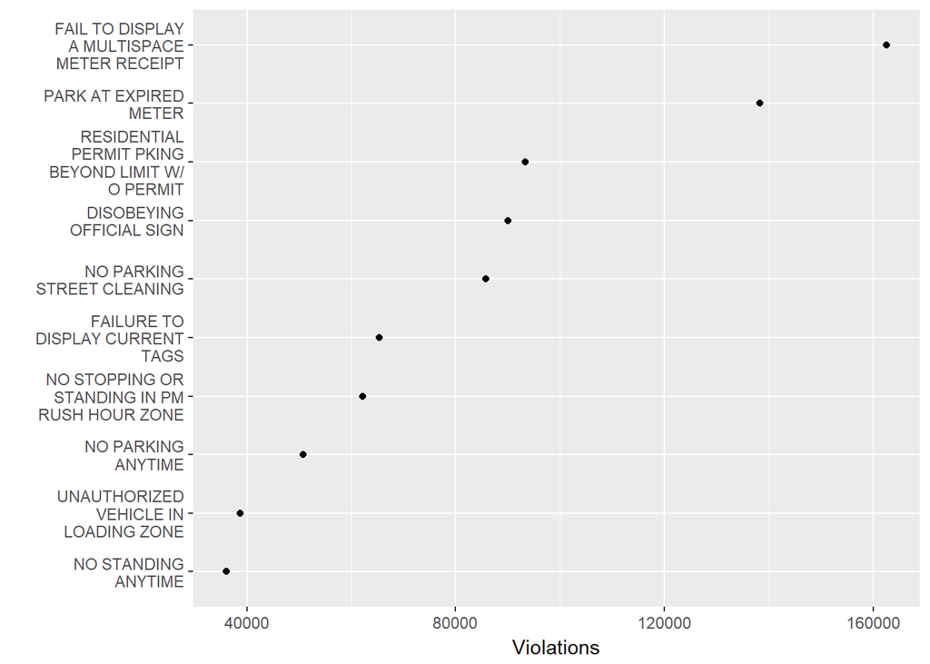

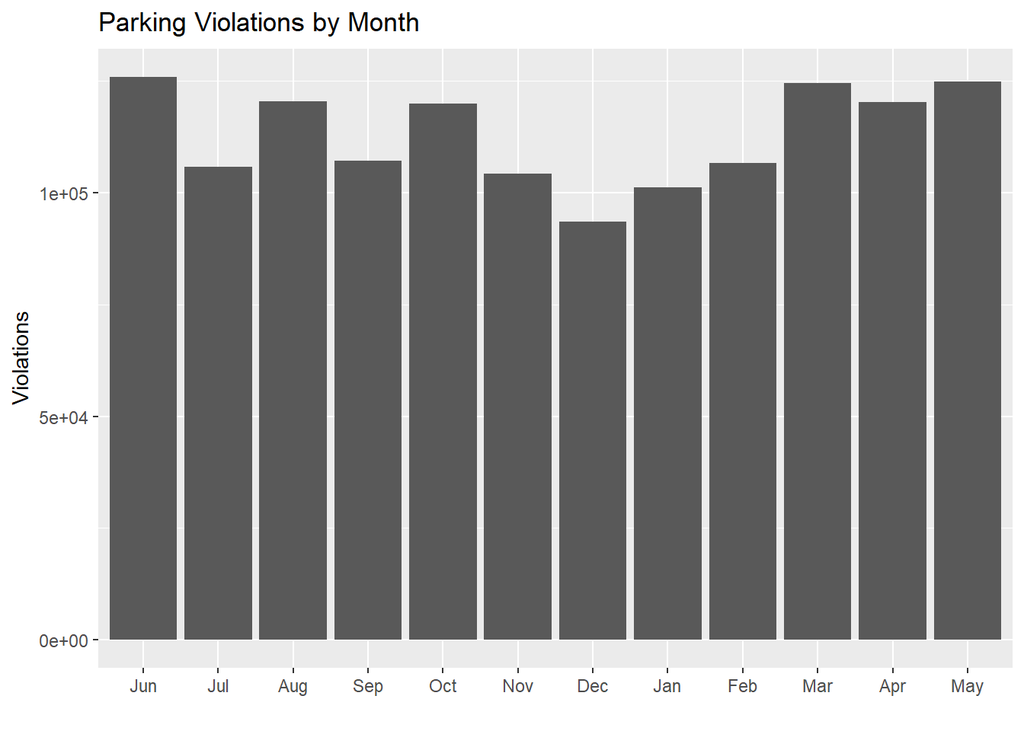

#### Top 10 Violation Locations

| LOCATION | Violations |
| --- | --- |
| 3200 BLOCK WATER ST NW SOUTH SIDE | 3540 |
| 1300 BLOCK H ST NE SOUTH SIDE | 2930 |
| 1300 BLOCK G ST NW SOUTH SIDE | 2641 |
| 1300 BLOCK CONNECTICUT AVE NW EA* | 2494 |
| 1300 BLOCK F ST NW NORTH SIDE | 2372 |
| 1300 BLOCK G ST NW NORTH SIDE | 2279 |
| 900 BLOCK K ST NW NORTH SIDE | 2075 |
| 700 BLOCK 7TH ST NW WEST SIDE | 2039 |
| 1300 BLOCK H ST NE NORTH SIDE | 1977 |
| 1400 BLOCK OKIE ST NE SOUTH SIDE | 1967 |
| 1600 BLOCK K ST NW SOUTH SIDE | 1967 |

#### Violations by Day of the Week

| Day | Violations |
| --- | --- |
| Thursday | 273785 |
| Wednesday | 273357 |
| Tuesday | 255016 |
| Friday | 223088 |
| Monday | 192582 |
| Saturday | 109258 |
| Sunday | 26869 |

#### Most Common Violation on each Day of the Week

| Day | VIOLATION_DESCRIPTION |
| --- | --- |
| Friday | FAIL TO DISPLAY A MULTISPACE METER RECEIPT |
| Monday | NO PARKING STREET CLEANING |
| Saturday | FAIL TO DISPLAY A MULTISPACE METER RECEIPT |
| Sunday | NO PARKING ANYTIME |
| Thursday | FAIL TO DISPLAY A MULTISPACE METER RECEIPT |
| Tuesday | FAIL TO DISPLAY A MULTISPACE METER RECEIPT |
| Wednesday | FAIL TO DISPLAY A MULTISPACE METER RECEIPT |

#### Violations by License Plate State

[figure not shown]

| RP_PLATE_STATE | Violations | Percentage |
| --- | --- | --- |
| DC | 388274 | 0.2867702 |
| FL | 14833 | 0.0109553 |
| MD | 482757 | 0.3565532 |
| NC | 12649 | 0.0093423 |
| NJ | 12163 | 0.0089833 |
| NY | 13359 | 0.0098666 |
| PA | 17515 | 0.0129362 |
| TX | 10084 | 0.0074478 |
| VA | 315116 | 0.2327374 |
| NA | 10347 | 0.0076421 |